# Proyección de matrícula universitaria en Puerto Rico

## Objetivo y alcance

Proyectar la matrícula de **subgrado y posgrado** de los censos iniciales de diez recintos hasta **2050–2051**.

- Año base: **2025–2026**.
- **2026–2027** aporta un contraste provisional y queda fuera del ajuste.
- El agregado comprende los diez recintos disponibles. **Falta Mayagüez**.
- La suma de recintos puede contar a una persona matriculada en varios recintos.

Las cifras futuras describen un escenario condicionado a parámetros históricos constantes.

## Fuentes y períodos de información

### Matrícula universitaria

100 archivos

Diez recintos y diez cursos, de **2017–2018 a 2026–2027**.

Los identificadores permiten enlazar a la misma persona entre años y recintos.

### Matrícula de duodécimo

Series públicas y privadas e informe escolar suministrado.

El futuro utiliza el cambio relativo de la población de **17 años** del escenario mediano.

**G12 representa matrícula de duodécimo.**

Las etapas 1 y 2 verificaron los períodos y reconstruyeron los censos. La etapa 3 estimó los parámetros y produjo la proyección preliminar.

## Qué matrícula se proyecta

### Resultado principal

**Subgrado + posgrado**

En 2025–2026:

29,830 matrículas.

Los otros registros sin homologar se presentan por separado. Los escolares quedan excluidos.

### Corte temporal

Se toma el **período inicial** de cada calendario: semestre, trimestre, Quarter o período anual.

La unión por identificador cuenta una sola vez a cada persona dentro del censo de cada recinto.

La falta del segundo semestre no determina si el censo inicial está consolidado. El contraste de 2026–2027 sigue provisional porque esa consolidación no se ha certificado.

## Composición del censo base

| Componente | Matrículas en 2025–2026 |
| --- | --- |
| Subgrado | 25,553 |
| Posgrado | 4,277 |
| Subgrado + posgrado | 29,830 |
| Otros no homologados | 3,502 |
| Escolares, excluidos de la proyección | 376 |

El subtotal sin escolares es **33,332**. El censo registrado contiene **33,708**, incluidos los escolares.

El componente Otros conserva categorías que requieren homologación. Su trayectoria se calcula aparte del resultado principal.

## Evolución histórica de la matrícula

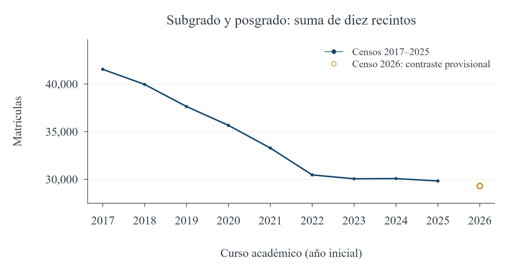

Suma de subgrado y posgrado de los diez recintos. El censo inicial de 2026–2027 aporta un contraste provisional y queda fuera del ajuste.

## Cómo se calcula la matrícula siguiente

**x**<sub>t+1</sub> = P<sup>T</sup>**x**<sub>t</sub> + **b** + α G12<sub>t</sub>**e**<sub>1</sub>

### Continuidad

La matriz **P** describe el paso entre estados de antigüedad dentro del mismo recinto y nivel de estudios.

El modelo conserva un estado para quienes tienen origen desconocido.

### Incorporaciones

**α G12** determina el ingreso desde secundaria.

**b** recoge las demás incorporaciones, según su distribución histórica entre estados.

Modelo de subgrado. El posgrado y Otros usan recurrencias de persistencia e incorporaciones. Una salida del censo no identifica su causa.

## Cohortes y continuidad

### Estados del subgrado

Años desde el ingreso:

**1, 2, 3, 4, 5 o más**, y **Sin origen**.

Estar en el estado 1 no basta para clasificar a alguien como nuevo ingreso desde secundaria.

### Quinto año o más

Se estiman por separado:

- El paso de cuarto a quinto año o más.
- La permanencia de quienes ya estaban en quinto año o más.

Cada flujo tiene su propio numerador.

La ventana central usa transiciones con destino en 2021–2025. Las demás incorporaciones al subgrado promedian 1,829 al año. Siete casos de ingreso quedan pendientes de revisión en toda la historia.

## Ingreso desde secundaria y G12

α = promedio de los cocientes entre nuevo ingreso consistente y G12 del curso anterior

- La captación central utiliza los ingresos de **2020–2021 a 2024–2025**.
- Sus denominadores son G12 **observado** de **2019–2020 a 2023–2024**.
- G12 de **2025–2026** alimenta el ingreso universitario de **2026–2027**.

G12 mide matrícula escolar. El cociente relaciona ese volumen con el ingreso universitario del curso siguiente y no estima directamente una tasa de ingreso entre graduados efectivos.

## Trayectoria escolar utilizada

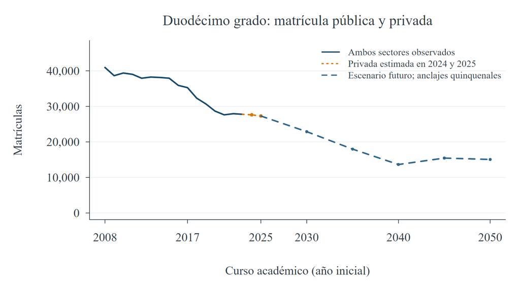

El sector privado de 2024–2025 y 2025–2026 es estimado. Desde la base, G12 sigue el cambio relativo de la población mediana de 17 años. Se interpola entre anclas quinquenales.

## Proyección central de subgrado y posgrado

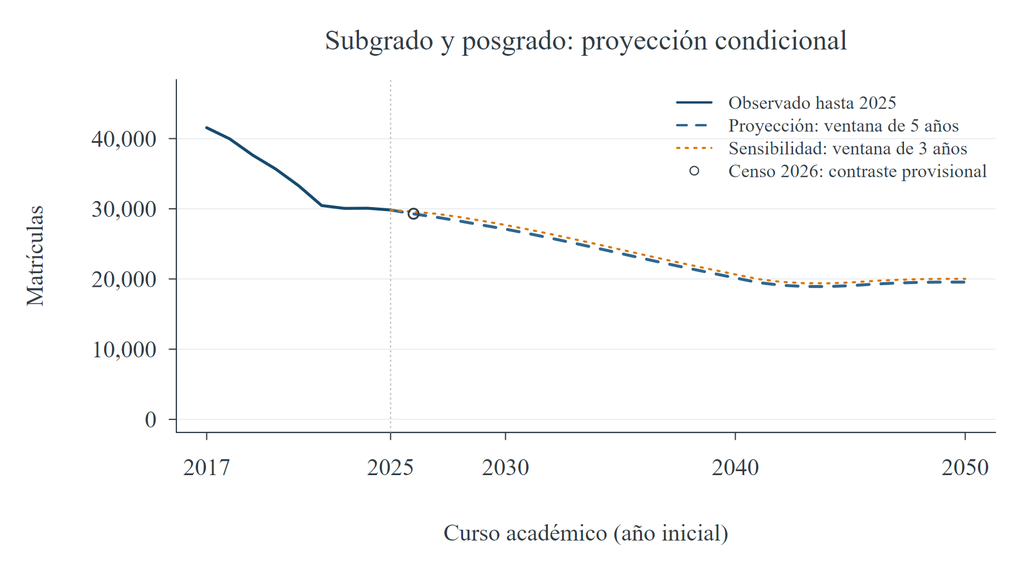

En 2050–2051: **19,554**, un cambio de **-34.45%** respecto a 2025–2026. Al sumar Otros, el subtotal sin escolares alcanza **21,585**.

## Proyección por recinto

| Recinto | 2025–2026 | 2030–2031 | 2050–2051 |
| --- | --- | --- | --- |
| Aguadilla | 1,960 | 1,686 | 1,128 |
| Arecibo | 2,707 | 2,465 | 1,667 |
| Bayamón | 2,610 | 2,414 | 1,606 |
| Carolina | 2,489 | 2,053 | 1,431 |
| Cayey | 2,026 | 1,828 | 1,176 |
| Ciencias Médicas | 1,809 | 1,822 | 1,820 |
| Humacao | 2,468 | 2,212 | 1,449 |
| Ponce | 2,391 | 2,025 | 1,355 |
| Río Piedras | 11,076 | 10,303 | 7,698 |
| Utuado | 294 | 295 | 223 |

Subgrado + posgrado. Base observada en 2025–2026. Los parámetros del escenario determinan las diferencias entre trayectorias.

## Diseño de la comprobación retrospectiva

- Predicciones de **un curso** para 2023–2024, 2024–2025 y 2025–2026.
- **30 combinaciones recinto–curso** por ventana histórica.
- Cada corte reconstruye cohortes y ajusta parámetros con datos universitarios disponibles hasta el curso anterior al objetivo.
- Referencia: mantener la matrícula del año anterior en cada recinto.

La comprobación depende de G12 del curso previo y de las versiones actuales de los archivos. No reproduce archivos históricos de disponibilidad ni acredita precisión a 25 años.

WMAPE = suma de errores absolutos dividida entre la matrícula observada total.

## Validación por componente

| Componente | Ventana 3 años | Ventana 5 años | Año anterior |
| --- | --- | --- | --- |
| Subgrado | 2.63% | 2.61% | 2.83% |
| Posgrado | 1.75% | 1.40% | 1.43% |
| Subgrado + posgrado | 2.51% | 2.38% | 2.53% |
| Otros no homologados | 47.22% | 51.43% | 59.39% |
| Subtotal sin escolares | 5.03% | 5.18% | 5.18% |

Para subgrado y posgrado, la ventana de cinco años obtiene **2.38%** frente a **2.53%** de la referencia. La mejora es modesta.

Otros tiene un error de 51.43% y requiere estudiar su variabilidad. Los porcentajes son errores de predicción a un curso.

## Diferencias de validación entre recintos

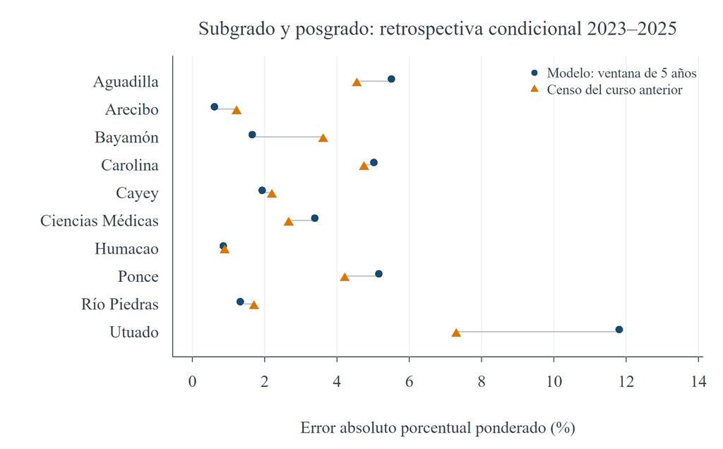

Subgrado + posgrado. Cada predicción usa el corte universitario correspondiente. El desempeño agregado no implica igual precisión en cada recinto.

## Contraste con 2026–2027

### Proyectado

29,272

Subgrado + posgrado

### Registrado en los archivos

29,298

Subgrado + posgrado

El error absoluto ponderado entre recintos es **2.23%**. La cercanía de las sumas contiene compensaciones entre recintos.

El ajuste universitario excluye 2026–2027. El contraste seguirá provisional hasta confirmar la consolidación de su censo inicial.

## Sensibilidad a la ventana histórica

| Ventana | 2030–2031 | 2040–2041 | 2050–2051 |
| --- | --- | --- | --- |
| 3 años | 27,690 | 20,650 | 20,017 |
| 5 años | 27,103 | 20,149 | 19,554 |

Las dos ventanas permiten examinar cuánto cambia el resultado al elegir otro período histórico. No constituyen límites de confianza ni de predicción.

Los parámetros universitarios permanecen constantes. El posgrado y las demás incorporaciones no siguen directamente la trayectoria de G12.

## Supuestos y alcance del preliminar

- Captación, continuidad y demás incorporaciones mantienen sus parámetros históricos.
- G12 sigue el escenario proporcional a la población de 17 años desde la base.
- La trayectoria alcanza un mínimo en 2044–2045 y luego se recupera parcialmente.
- Otros requiere homologación y estudio de sus cambios recientes.
- La proyección aún no propaga toda la incertidumbre escolar, demográfica y universitaria.

Quedan pendientes la inclusión de Mayagüez y la confirmación del censo inicial de 2026–2027. Las salidas del censo no distinguen graduación, abandono, pausa o traslado.

Proyección de matrícula universitaria en Puerto Rico

¡Muchas gracias!